# **BIMS 8382**

Spring 2018, Feb 12 - Mar 26  
Mondays, 2:00-5:00pm

*Please sign in and let me know if you had installation issues.*

## Logistics

### Meetings

- Mondays, Feb 12 - Mar 26 *(No exam – final class held March 26.)*
- 2-5pm in this room (BIMS education center)

### Instructors

Stephen Turner (Bioinformatics Core Director, PHS)  
turner@virginia.edu

Pete Nagraj (Data Scientist, SOM Research Computing)  
vpn7n@virginia.edu

### Course Website

**http://bims.fun**

## Agenda

Subject to change!

1. Week 1 (Feb 12): Intro to R
2. Week 2 (Feb 19): Advanced Data Manipulation & Tidy Data
3. Week 3 (Feb 26): Advanced Data Visualization with ggplot2
4. Week 4 (Mar 5): Reproducible Research & Dynamic Documents
5. Week 5 (Mar 12): Essential Statistics
6. Week 6 (Mar 19): Survival Analysis
7. Week 7 (Mar 26): Predictive Modeling & Forecasting*

(* = or other options… RNA-seq, phylogenetic trees, …)

## Week 1 (today!): Intro to R

Novice-level introduction to the R, RStudio, and basic functionality such as creating variables, getting help, using data frames, basic plotting, and reading/writing files.

**Why R?**

- Free
- Huge community support
- 10,000+ free add-on packages
- [Bioconductor](http://bioconductor.org): huge resource for bioinformatics-specific functionality, packages, data, …
- [Amazing graphics](https://www.google.com/search?q=ggplot2&tbm=isch)
- Reproducible research (Week 4)
- Tons of resources ([StackOverflow](http://stackoverflow.com/questions/tagged/r), [Coursera](https://www.coursera.org/specializations/jhu-data-science), …)

## Week 2 (Feb 19): Advanced Data Manipulation & Tidy Data

**[Janitor work](https://www.nytimes.com/2014/08/18/technology/for-big-data-scientists-hurdle-to-insights-is-janitor-work.html):** Filtering, reshaping, subsetting, split-apply-combine, joining, etc.

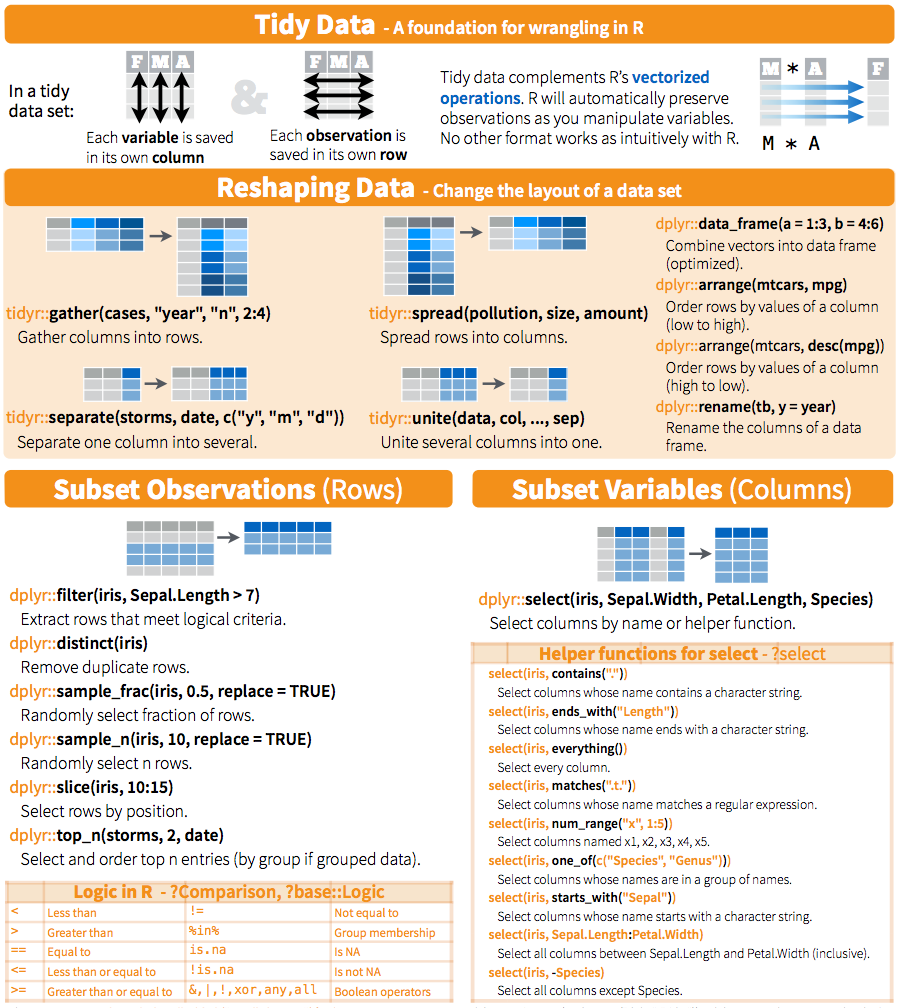

## Week 3 (Feb 26): Advanced Data Visualization with ggplot2

[figure not shown]

## Week 4 (Mar 5): Reproducible Research & Dynamic Documents

- What’s reproducible research all about?
- How to do it with **[RMarkdown](http://rmarkdown.rstudio.com/)**.

## Week 5 (Mar 12): Essential Statistics

1. Descriptive statistics & Exploratory data analysis (EDA)
2. Continuous variable statistics
   - T-tests
   - Wilcoxon / Mann-Whitney U tests
   - ANOVA
   - Linear models & multiple regression
3. Discrete variable statistics
   - Contingency tables
   - Chi-square & Fisher exact tests
   - Logistic regression
4. *If time allows*: Power & sample size analysis
5. *Bonus*: Model tidying and extraction

## Week 6 (Mar 19): Survival Analysis

1. Survival analysis overview, definitions
2. Survival analysis in R using built-in data
   - Survival curves + life tables
   - Kaplan-Meier curves
   - Cox proportional hazards regression
3. Example with TCGA data

## Week 7 (Mar 26)

### *Option A:* Predictive Modeling & Forecasting

1. Data pre-processing: feature extraction & imputation
2. Model training, tuning, resampling, and prediction
3. Forecasting at scale

### *Option B*: Introduction to RNA-seq Data Analysis

1. Data overview: source, pre-processing, structure
2. Processing and analysis with DESeq2
3. Pathway analysis

### *Option C*: Phylogenetic Trees

1. Importing phylogenetic tree data
2. Drawing and annotating phylogenetic trees

## Rubric

- Pass/fail.
- Assignments will be given out at the end of each period.
- Upload programming assignments to Collab.
- We’ll review the homework at the beginning of the next period.